# examples_0515

Let function $f$ be defined by the algebraic expression below:

$$f(x)=\frac{x}{4}+3$$

Evaluate $f(24)$.

$$f(24)=\frac{24}{4}+3$$

$$f(24)=6+3$$

$$f(24)=9$$

Let function $f$ be defined by the algebraic expression below:

$$f(x)=\frac{x-4}{5}$$

Evaluate $f(-41)$.

$$f(-41)=\frac{-41-4}{5}$$

$$f(-41)=\frac{-45}{5}$$

$$f(-41)=-9$$

Let function $f$ be defined by the algebraic expression below:

$$f(x)=\frac{x}{7}-2$$

Evaluate $f(-21)$.

$$f(-21)=\frac{-21}{7}-2$$

$$f(-21)=-3-2$$

$$f(-21)=-5$$

Let function $f$ be defined by the algebraic expression below:

$$f(x)=\frac{x+2}{6}$$

Evaluate $f(16)$.

$$f(16)=\frac{16+2}{6}$$

$$f(16)=\frac{18}{6}$$

$$f(16)=3$$

Let function $f$ be defined by the algebraic expression below:

$$f(x)=\frac{x-2}{7}$$

Evaluate $f(37)$.

$$f(37)=\frac{37-2}{7}$$

$$f(37)=\frac{35}{7}$$

$$f(37)=5$$

Let function $f$ be defined by the algebraic expression below:

$$f(x)=\frac{x+8}{4}$$

Evaluate $f(0)$.

$$f(0)=\frac{0+8}{4}$$

$$f(0)=\frac{8}{4}$$

$$f(0)=2$$

Let function $f$ be defined by the algebraic expression below:

$$f(x)=\frac{x-3}{9}$$

Evaluate $f(66)$.

$$f(66)=\frac{66-3}{9}$$

$$f(66)=\frac{63}{9}$$

$$f(66)=7$$

Let function $f$ be defined by the algebraic expression below:

$$f(x)=\frac{x}{4}-9$$

Evaluate $f(28)$.

$$f(28)=\frac{28}{4}-9$$

$$f(28)=7-9$$

$$f(28)=-2$$

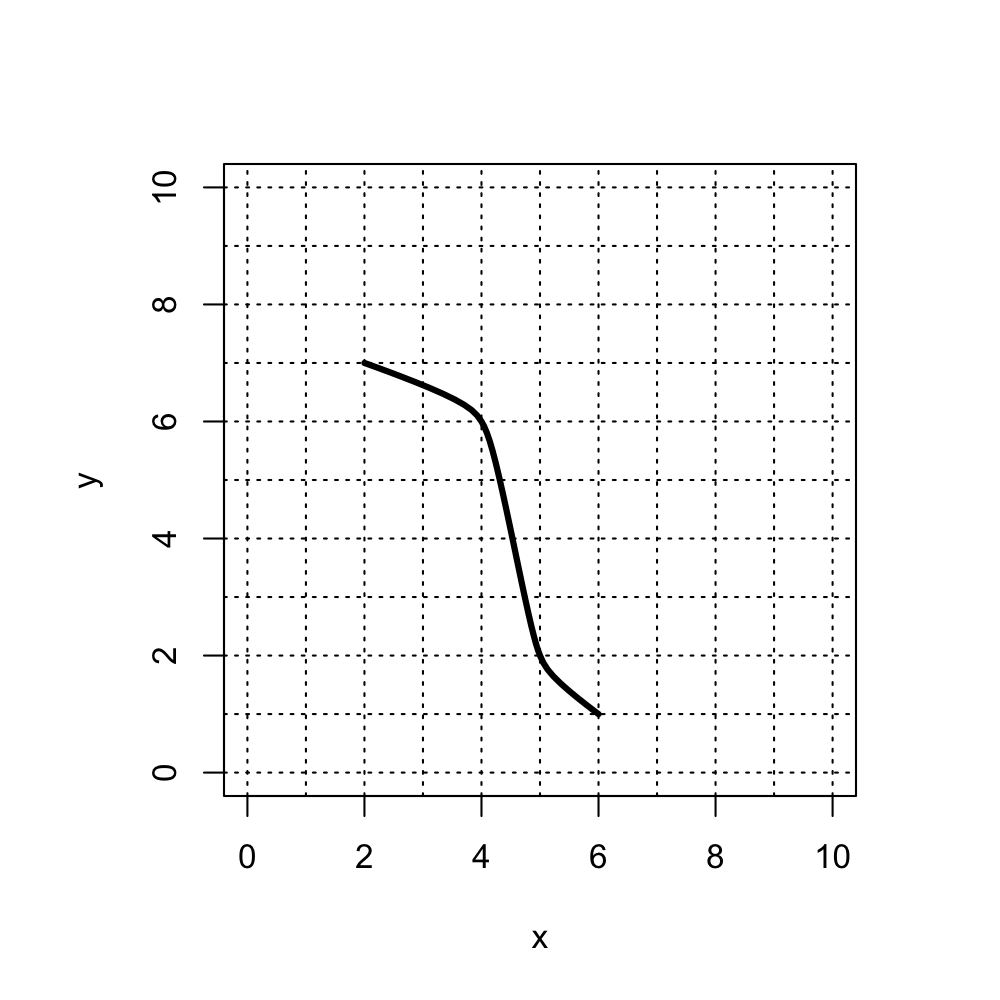

- Is $y$ a function of $x$?
- Is $x$ a function of $y$?
- Do we have a one-to-one function?

It is best to visualize the vertical line test and the horizontal line test. If you can draw a vertical line through 2 (or more) points, then $y$ is not a function of $x$. If you can draw a horizontal line through 2 (or more) points, then $x$ is not a function of $y$.

The function is one-to-one if and only if $y$ is a function of $x$ and $x$ is a function of $y$.

Below, if the function is not one-to-one, some failed line tests are shown:

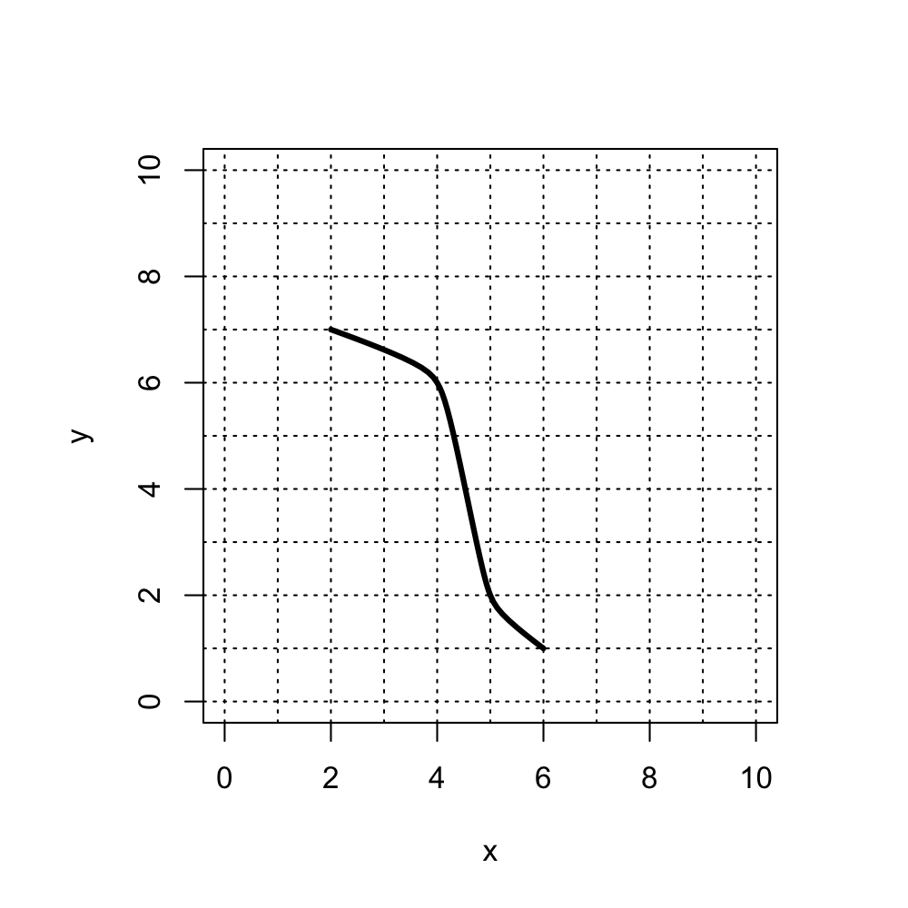

The curve passed the vertical line test and the horizontal line test. So, we have a one-to-one function.

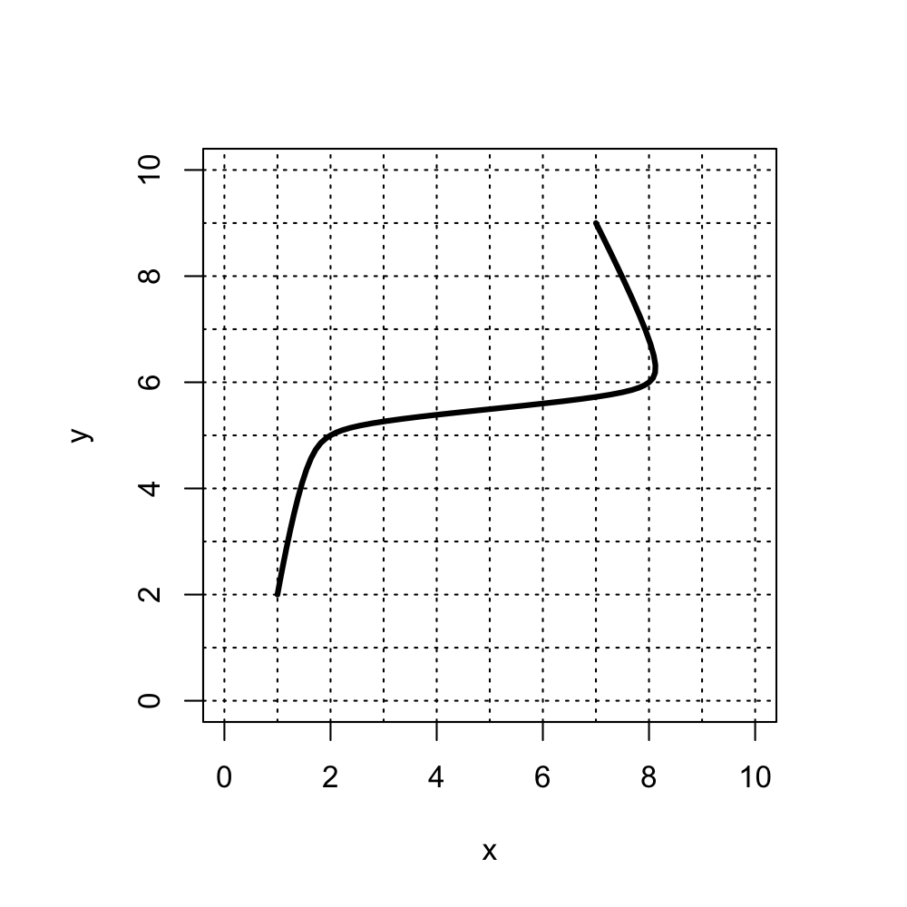

- Is $y$ a function of $x$?
- Is $x$ a function of $y$?
- Do we have a one-to-one function?

It is best to visualize the vertical line test and the horizontal line test. If you can draw a vertical line through 2 (or more) points, then $y$ is not a function of $x$. If you can draw a horizontal line through 2 (or more) points, then $x$ is not a function of $y$.

The function is one-to-one if and only if $y$ is a function of $x$ and $x$ is a function of $y$.

Below, if the function is not one-to-one, some failed line tests are shown:

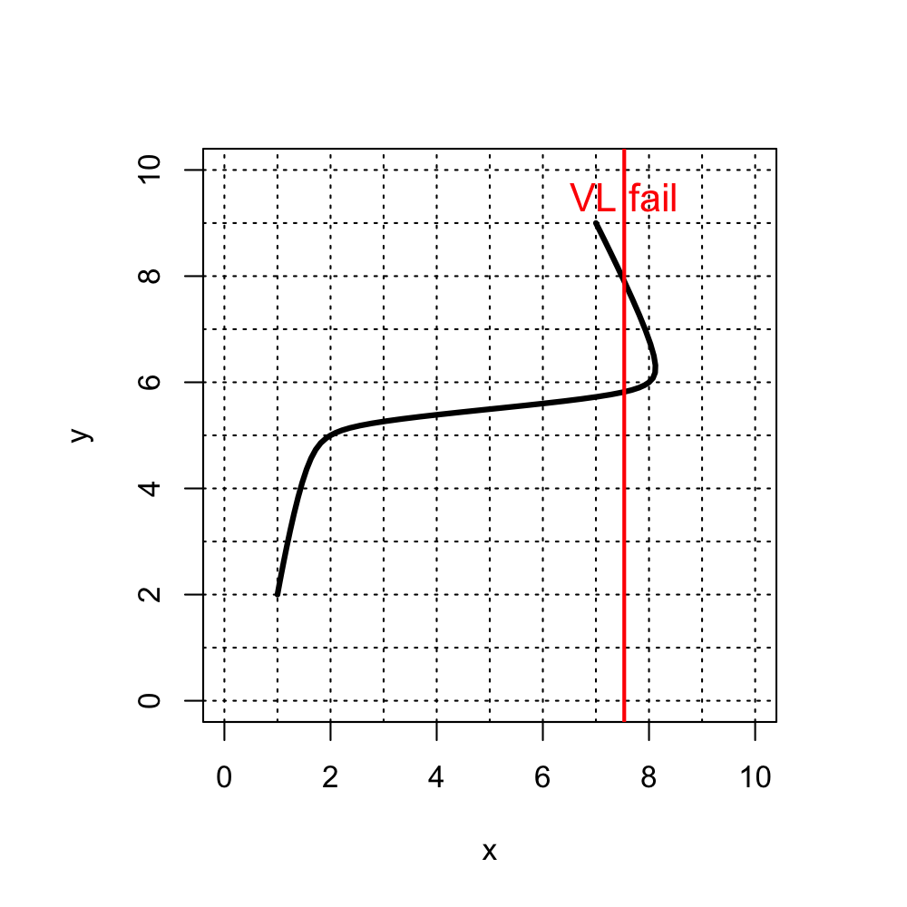

The curve failed the vertical line test. So $y$ is not a function of $x$. Also, we do not have a one-to-one function.

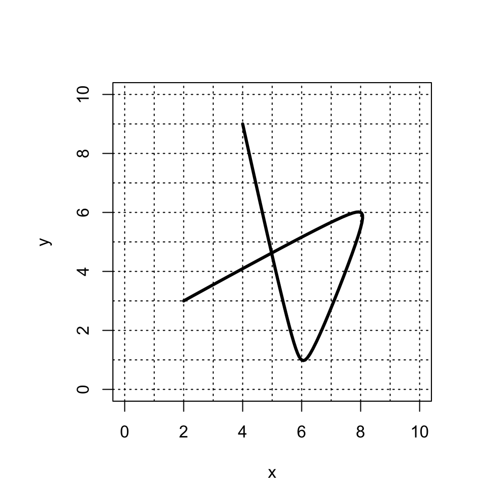

- Is $y$ a function of $x$?
- Is $x$ a function of $y$?
- Do we have a one-to-one function?

It is best to visualize the vertical line test and the horizontal line test. If you can draw a vertical line through 2 (or more) points, then $y$ is not a function of $x$. If you can draw a horizontal line through 2 (or more) points, then $x$ is not a function of $y$.

The function is one-to-one if and only if $y$ is a function of $x$ and $x$ is a function of $y$.

Below, if the function is not one-to-one, some failed line tests are shown:

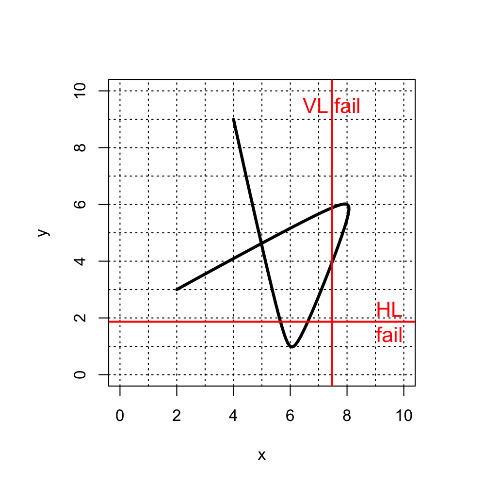

The curve failed both tests. So $y$ is not a function of $x$. Also, So $x$ is not a function of $y$. Also, we do not have a one-to-one function.

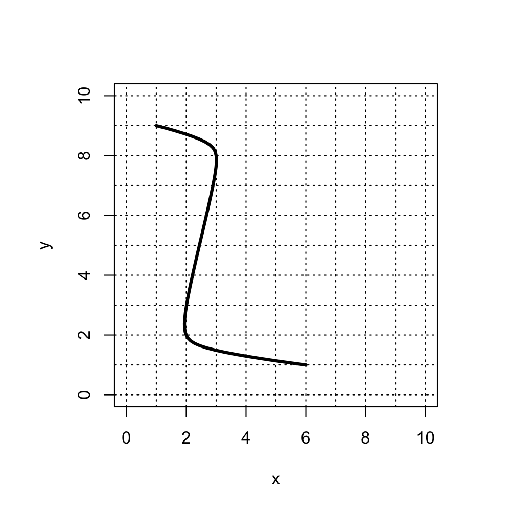

- Is $y$ a function of $x$?
- Is $x$ a function of $y$?
- Do we have a one-to-one function?

It is best to visualize the vertical line test and the horizontal line test. If you can draw a vertical line through 2 (or more) points, then $y$ is not a function of $x$. If you can draw a horizontal line through 2 (or more) points, then $x$ is not a function of $y$.

The function is one-to-one if and only if $y$ is a function of $x$ and $x$ is a function of $y$.

Below, if the function is not one-to-one, some failed line tests are shown:

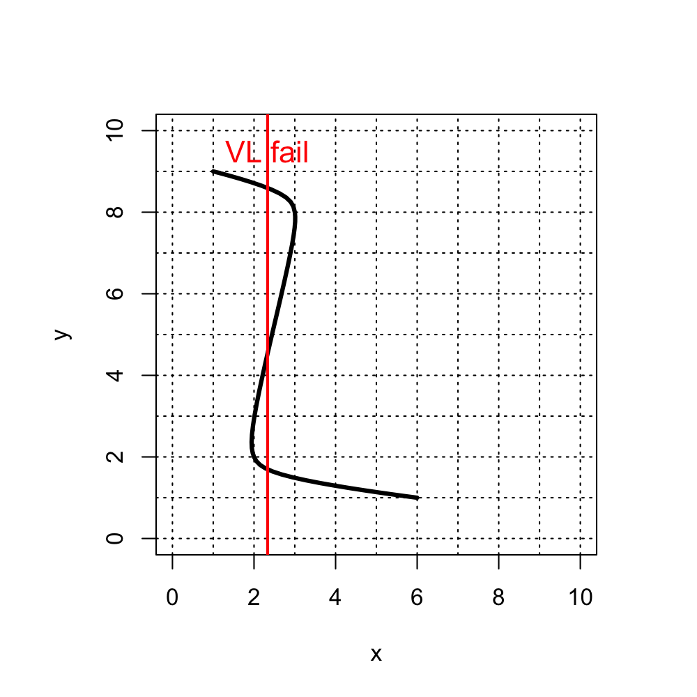

The curve failed the vertical line test. So $y$ is not a function of $x$. Also, we do not have a one-to-one function.

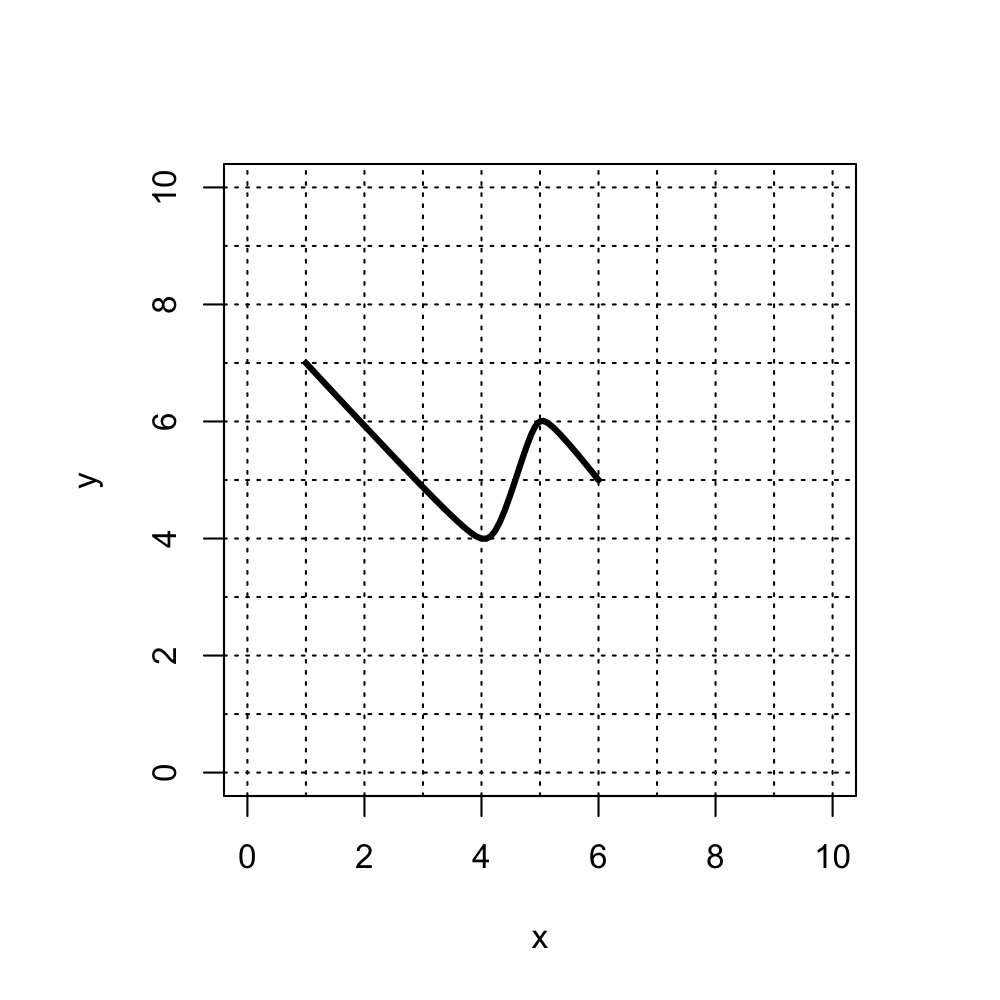

- Is $y$ a function of $x$?
- Is $x$ a function of $y$?
- Do we have a one-to-one function?

It is best to visualize the vertical line test and the horizontal line test. If you can draw a vertical line through 2 (or more) points, then $y$ is not a function of $x$. If you can draw a horizontal line through 2 (or more) points, then $x$ is not a function of $y$.

The function is one-to-one if and only if $y$ is a function of $x$ and $x$ is a function of $y$.

Below, if the function is not one-to-one, some failed line tests are shown:

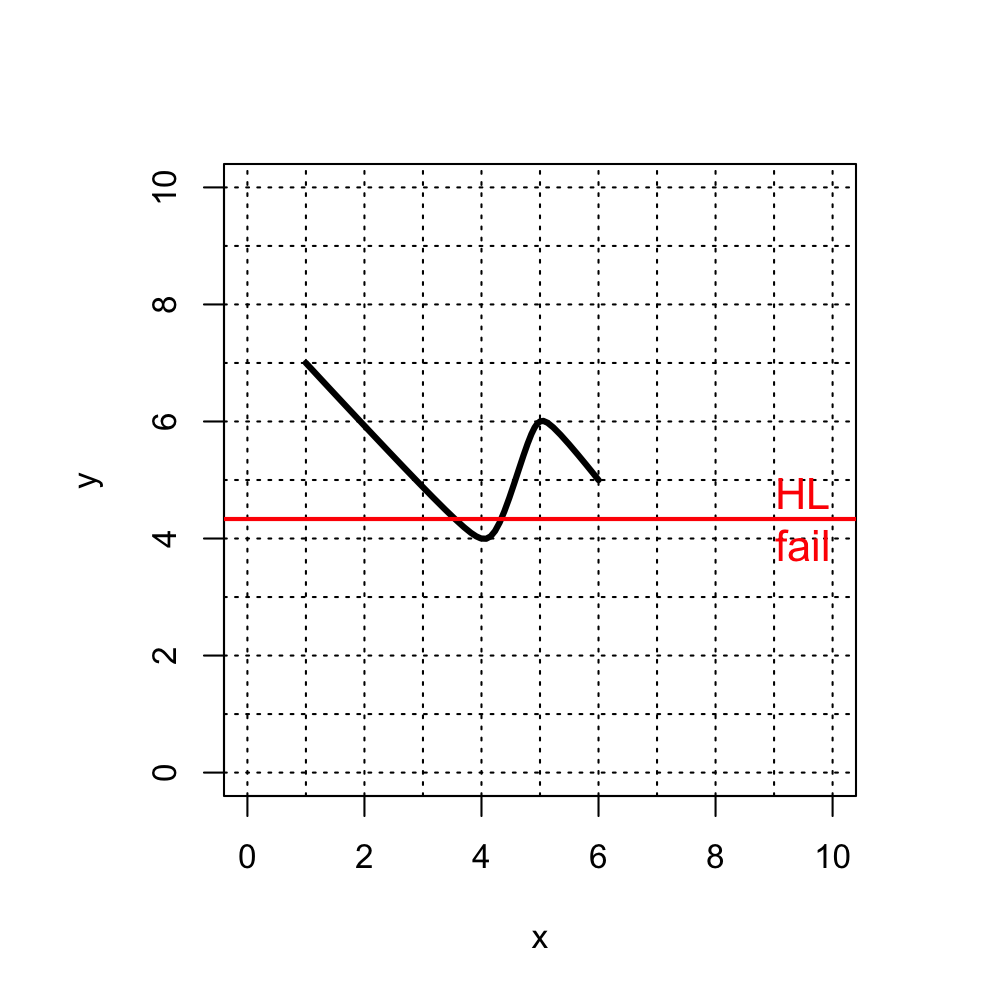

The curve failed the horizontal line test. So $x$ is not a function of $y$. Also, we do not have a one-to-one function.

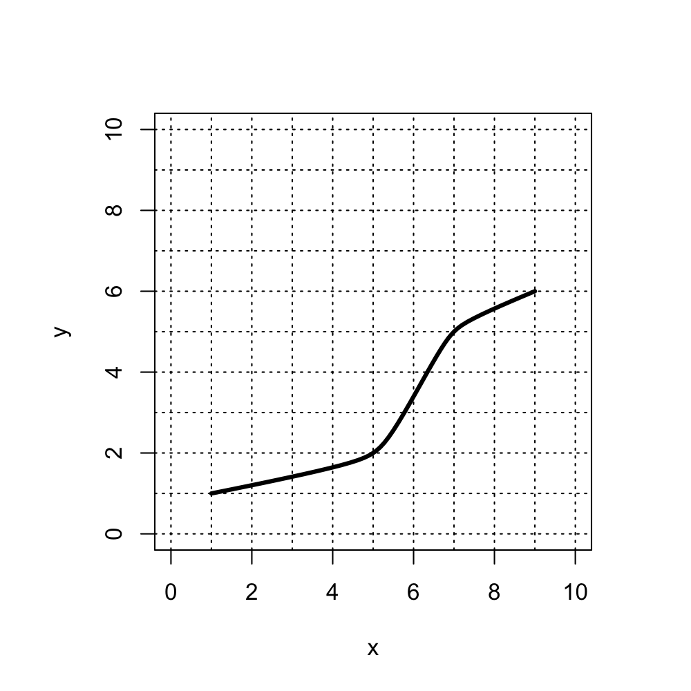

- Is $y$ a function of $x$?
- Is $x$ a function of $y$?
- Do we have a one-to-one function?

It is best to visualize the vertical line test and the horizontal line test. If you can draw a vertical line through 2 (or more) points, then $y$ is not a function of $x$. If you can draw a horizontal line through 2 (or more) points, then $x$ is not a function of $y$.

The function is one-to-one if and only if $y$ is a function of $x$ and $x$ is a function of $y$.

Below, if the function is not one-to-one, some failed line tests are shown:

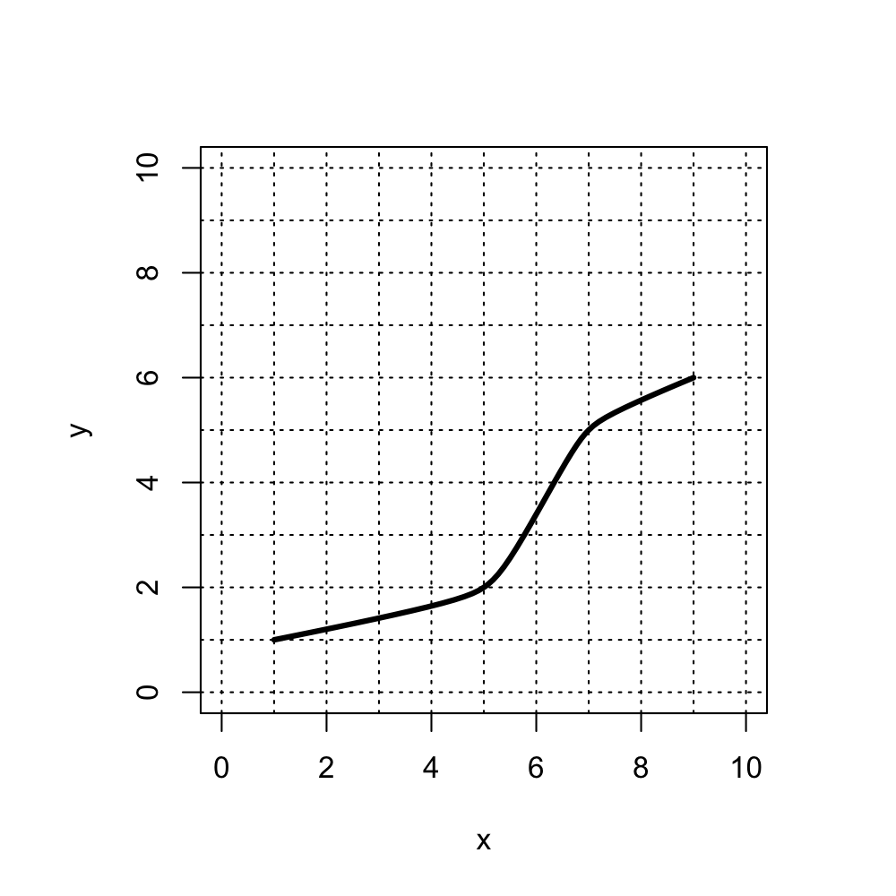

The curve passed the vertical line test and the horizontal line test. So, we have a one-to-one function.

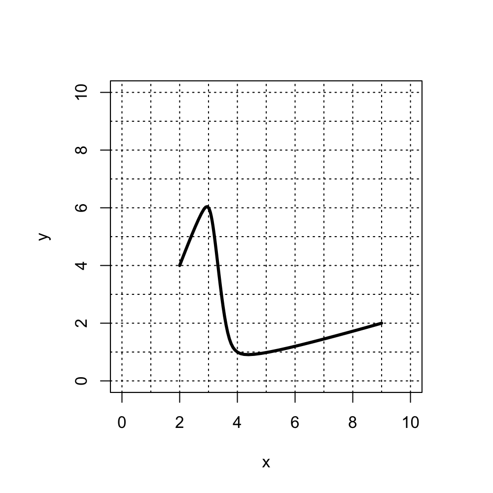

- Is $y$ a function of $x$?
- Is $x$ a function of $y$?
- Do we have a one-to-one function?

It is best to visualize the vertical line test and the horizontal line test. If you can draw a vertical line through 2 (or more) points, then $y$ is not a function of $x$. If you can draw a horizontal line through 2 (or more) points, then $x$ is not a function of $y$.

The function is one-to-one if and only if $y$ is a function of $x$ and $x$ is a function of $y$.

Below, if the function is not one-to-one, some failed line tests are shown:

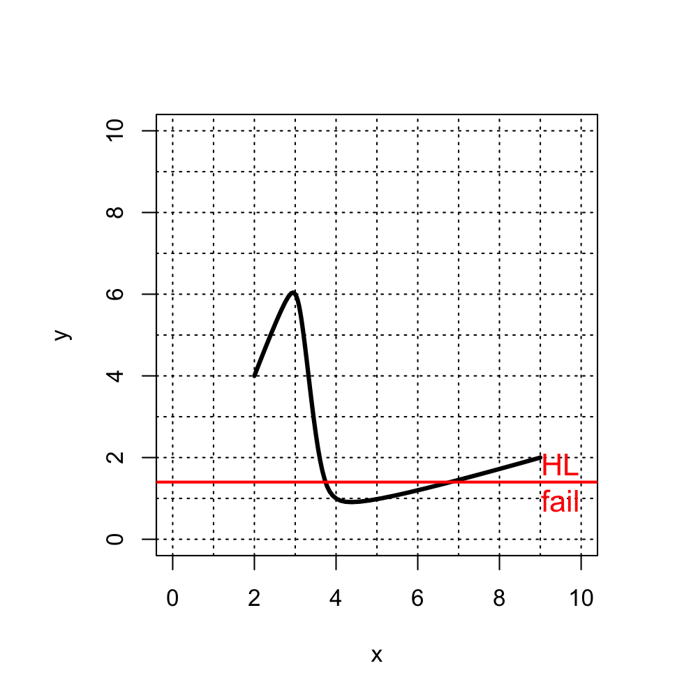

The curve failed the horizontal line test. So $x$ is not a function of $y$. Also, we do not have a one-to-one function.

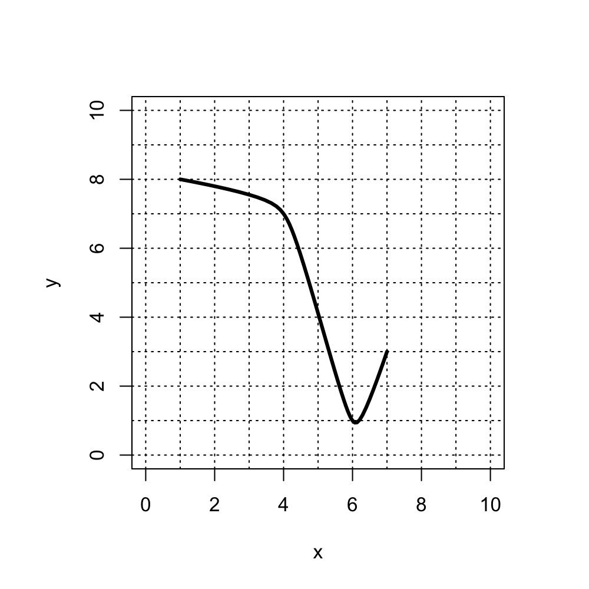

- Is $y$ a function of $x$?
- Is $x$ a function of $y$?
- Do we have a one-to-one function?

It is best to visualize the vertical line test and the horizontal line test. If you can draw a vertical line through 2 (or more) points, then $y$ is not a function of $x$. If you can draw a horizontal line through 2 (or more) points, then $x$ is not a function of $y$.

The function is one-to-one if and only if $y$ is a function of $x$ and $x$ is a function of $y$.

Below, if the function is not one-to-one, some failed line tests are shown:

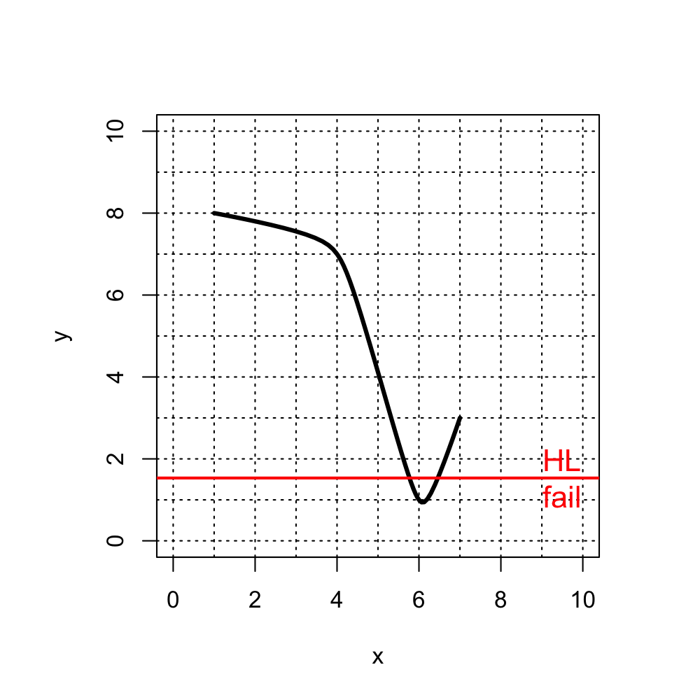

The curve failed the horizontal line test. So $x$ is not a function of $y$. Also, we do not have a one-to-one function.

Simplify the following powers of $i$.

- $i^{20}=$
- $i^{25}=$
- $i^{50}=$
- $i^{55}=$

For any positive integer $n$, we can evaluate $i^n$ by determining the remainder when $n$ is divided by 4.

| Remainder of $n/4$ | $i^n$ |
| --- | --- |
| 0 | $1$ |
| 1 | $i$ |
| 2 | $-1$ |
| 3 | $-i$ |

In computer programming, the [modulo operator](https://en.wikipedia.org/wiki/Modulo) returns the remainder. This operation is used so frequently, that it is often abbreviated to a single symbol (for example, in Python, `5%2` represents the remainder when 5 is divided by 2.)

I will represent the remainders using the [Desmos](https://www.desmos.com/calculator) notation.

- $\mathrm{mod}(20,4)=0$ so $i^{20}=1$
- $\mathrm{mod}(25,4)=1$ so $i^{25}=i$
- $\mathrm{mod}(50,4)=2$ so $i^{50}=-1$
- $\mathrm{mod}(55,4)=3$ so $i^{55}=-i$

To find the remainder using a scientific calculator, I would divide by 4, [floor](https://en.wikipedia.org/wiki/Floor_and_ceiling_functions) the result, multiply by 4, and subtract that amount from the original.

$$\mathrm{mod}(x,4)~=~x-4\cdot
\left\lfloor\frac{x}{4}\right\rfloor$$

Simplify the following powers of $i$.

- $i^{23}=$
- $i^{29}=$
- $i^{52}=$
- $i^{58}=$

For any positive integer $n$, we can evaluate $i^n$ by determining the remainder when $n$ is divided by 4.

| Remainder of $n/4$ | $i^n$ |
| --- | --- |
| 0 | $1$ |
| 1 | $i$ |
| 2 | $-1$ |
| 3 | $-i$ |

In computer programming, the [modulo operator](https://en.wikipedia.org/wiki/Modulo) returns the remainder. This operation is used so frequently, that it is often abbreviated to a single symbol (for example, in Python, `5%2` represents the remainder when 5 is divided by 2.)

I will represent the remainders using the [Desmos](https://www.desmos.com/calculator) notation.

- $\mathrm{mod}(23,4)=3$ so $i^{23}=-i$
- $\mathrm{mod}(29,4)=1$ so $i^{29}=i$
- $\mathrm{mod}(52,4)=0$ so $i^{52}=1$
- $\mathrm{mod}(58,4)=2$ so $i^{58}=-1$

To find the remainder using a scientific calculator, I would divide by 4, [floor](https://en.wikipedia.org/wiki/Floor_and_ceiling_functions) the result, multiply by 4, and subtract that amount from the original.

$$\mathrm{mod}(x,4)~=~x-4\cdot
\left\lfloor\frac{x}{4}\right\rfloor$$

Simplify the following powers of $i$.

- $i^{27}=$
- $i^{38}=$
- $i^{49}=$
- $i^{60}=$

For any positive integer $n$, we can evaluate $i^n$ by determining the remainder when $n$ is divided by 4.

| Remainder of $n/4$ | $i^n$ |
| --- | --- |
| 0 | $1$ |
| 1 | $i$ |
| 2 | $-1$ |
| 3 | $-i$ |

In computer programming, the [modulo operator](https://en.wikipedia.org/wiki/Modulo) returns the remainder. This operation is used so frequently, that it is often abbreviated to a single symbol (for example, in Python, `5%2` represents the remainder when 5 is divided by 2.)

I will represent the remainders using the [Desmos](https://www.desmos.com/calculator) notation.

- $\mathrm{mod}(27,4)=3$ so $i^{27}=-i$
- $\mathrm{mod}(38,4)=2$ so $i^{38}=-1$
- $\mathrm{mod}(49,4)=1$ so $i^{49}=i$
- $\mathrm{mod}(60,4)=0$ so $i^{60}=1$

To find the remainder using a scientific calculator, I would divide by 4, [floor](https://en.wikipedia.org/wiki/Floor_and_ceiling_functions) the result, multiply by 4, and subtract that amount from the original.

$$\mathrm{mod}(x,4)~=~x-4\cdot
\left\lfloor\frac{x}{4}\right\rfloor$$

Simplify the following powers of $i$.

- $i^{24}=$
- $i^{37}=$
- $i^{46}=$
- $i^{55}=$

For any positive integer $n$, we can evaluate $i^n$ by determining the remainder when $n$ is divided by 4.

| Remainder of $n/4$ | $i^n$ |
| --- | --- |
| 0 | $1$ |
| 1 | $i$ |
| 2 | $-1$ |
| 3 | $-i$ |

In computer programming, the [modulo operator](https://en.wikipedia.org/wiki/Modulo) returns the remainder. This operation is used so frequently, that it is often abbreviated to a single symbol (for example, in Python, `5%2` represents the remainder when 5 is divided by 2.)

I will represent the remainders using the [Desmos](https://www.desmos.com/calculator) notation.

- $\mathrm{mod}(24,4)=0$ so $i^{24}=1$
- $\mathrm{mod}(37,4)=1$ so $i^{37}=i$
- $\mathrm{mod}(46,4)=2$ so $i^{46}=-1$
- $\mathrm{mod}(55,4)=3$ so $i^{55}=-i$

To find the remainder using a scientific calculator, I would divide by 4, [floor](https://en.wikipedia.org/wiki/Floor_and_ceiling_functions) the result, multiply by 4, and subtract that amount from the original.

$$\mathrm{mod}(x,4)~=~x-4\cdot
\left\lfloor\frac{x}{4}\right\rfloor$$

Simplify the following powers of $i$.

- $i^{30}=$
- $i^{44}=$
- $i^{49}=$
- $i^{59}=$

For any positive integer $n$, we can evaluate $i^n$ by determining the remainder when $n$ is divided by 4.

| Remainder of $n/4$ | $i^n$ |
| --- | --- |
| 0 | $1$ |
| 1 | $i$ |
| 2 | $-1$ |
| 3 | $-i$ |

In computer programming, the [modulo operator](https://en.wikipedia.org/wiki/Modulo) returns the remainder. This operation is used so frequently, that it is often abbreviated to a single symbol (for example, in Python, `5%2` represents the remainder when 5 is divided by 2.)

I will represent the remainders using the [Desmos](https://www.desmos.com/calculator) notation.

- $\mathrm{mod}(30,4)=2$ so $i^{30}=-1$
- $\mathrm{mod}(44,4)=0$ so $i^{44}=1$
- $\mathrm{mod}(49,4)=1$ so $i^{49}=i$
- $\mathrm{mod}(59,4)=3$ so $i^{59}=-i$

To find the remainder using a scientific calculator, I would divide by 4, [floor](https://en.wikipedia.org/wiki/Floor_and_ceiling_functions) the result, multiply by 4, and subtract that amount from the original.

$$\mathrm{mod}(x,4)~=~x-4\cdot
\left\lfloor\frac{x}{4}\right\rfloor$$

Simplify the following powers of $i$.

- $i^{30}=$
- $i^{39}=$
- $i^{44}=$
- $i^{53}=$

For any positive integer $n$, we can evaluate $i^n$ by determining the remainder when $n$ is divided by 4.

| Remainder of $n/4$ | $i^n$ |
| --- | --- |
| 0 | $1$ |
| 1 | $i$ |
| 2 | $-1$ |
| 3 | $-i$ |

In computer programming, the [modulo operator](https://en.wikipedia.org/wiki/Modulo) returns the remainder. This operation is used so frequently, that it is often abbreviated to a single symbol (for example, in Python, `5%2` represents the remainder when 5 is divided by 2.)

I will represent the remainders using the [Desmos](https://www.desmos.com/calculator) notation.

- $\mathrm{mod}(30,4)=2$ so $i^{30}=-1$
- $\mathrm{mod}(39,4)=3$ so $i^{39}=-i$
- $\mathrm{mod}(44,4)=0$ so $i^{44}=1$
- $\mathrm{mod}(53,4)=1$ so $i^{53}=i$

To find the remainder using a scientific calculator, I would divide by 4, [floor](https://en.wikipedia.org/wiki/Floor_and_ceiling_functions) the result, multiply by 4, and subtract that amount from the original.

$$\mathrm{mod}(x,4)~=~x-4\cdot
\left\lfloor\frac{x}{4}\right\rfloor$$

Simplify the following powers of $i$.

- $i^{35}=$
- $i^{40}=$
- $i^{50}=$
- $i^{57}=$

For any positive integer $n$, we can evaluate $i^n$ by determining the remainder when $n$ is divided by 4.

| Remainder of $n/4$ | $i^n$ |
| --- | --- |
| 0 | $1$ |
| 1 | $i$ |
| 2 | $-1$ |
| 3 | $-i$ |

In computer programming, the [modulo operator](https://en.wikipedia.org/wiki/Modulo) returns the remainder. This operation is used so frequently, that it is often abbreviated to a single symbol (for example, in Python, `5%2` represents the remainder when 5 is divided by 2.)

I will represent the remainders using the [Desmos](https://www.desmos.com/calculator) notation.

- $\mathrm{mod}(35,4)=3$ so $i^{35}=-i$
- $\mathrm{mod}(40,4)=0$ so $i^{40}=1$
- $\mathrm{mod}(50,4)=2$ so $i^{50}=-1$
- $\mathrm{mod}(57,4)=1$ so $i^{57}=i$

To find the remainder using a scientific calculator, I would divide by 4, [floor](https://en.wikipedia.org/wiki/Floor_and_ceiling_functions) the result, multiply by 4, and subtract that amount from the original.

$$\mathrm{mod}(x,4)~=~x-4\cdot
\left\lfloor\frac{x}{4}\right\rfloor$$

Simplify the following powers of $i$.

- $i^{23}=$
- $i^{30}=$
- $i^{48}=$
- $i^{57}=$

For any positive integer $n$, we can evaluate $i^n$ by determining the remainder when $n$ is divided by 4.

| Remainder of $n/4$ | $i^n$ |
| --- | --- |
| 0 | $1$ |
| 1 | $i$ |
| 2 | $-1$ |
| 3 | $-i$ |

In computer programming, the [modulo operator](https://en.wikipedia.org/wiki/Modulo) returns the remainder. This operation is used so frequently, that it is often abbreviated to a single symbol (for example, in Python, `5%2` represents the remainder when 5 is divided by 2.)

I will represent the remainders using the [Desmos](https://www.desmos.com/calculator) notation.

- $\mathrm{mod}(23,4)=3$ so $i^{23}=-i$
- $\mathrm{mod}(30,4)=2$ so $i^{30}=-1$
- $\mathrm{mod}(48,4)=0$ so $i^{48}=1$
- $\mathrm{mod}(57,4)=1$ so $i^{57}=i$

To find the remainder using a scientific calculator, I would divide by 4, [floor](https://en.wikipedia.org/wiki/Floor_and_ceiling_functions) the result, multiply by 4, and subtract that amount from the original.

$$\mathrm{mod}(x,4)~=~x-4\cdot
\left\lfloor\frac{x}{4}\right\rfloor$$

Let $z_1$ and $z_2$ be two [complex numbers](https://en.wikipedia.org/wiki/Complex_number).
$$z_1 = 1-2i$$
$$z_2 = 8+6i$$
Find the product.
$$z_1 \cdot z_2 = ~?$$

*Type your answer precisely, with no spaces, using digits, "-", "+", and "i". If the real term is nonzero, put it first. If either component is zero, do not include that term. If both components are zero, type "0" without the quotes. Instead of writing "1i" or "-1i" just write "i" or "-i".*

To multiply complex numbers, follow a procedure similar to [FOIL](https://en.wikipedia.org/wiki/FOIL_method), but remember $i^2=-1$.

$$(1-2i)(8+6i)$$

$$\Big((1)+(-2i)\Big)\Big((8)+(6i)\Big)$$

$$(1)(8)~~+~~(1)(6i)~~+~~(-2i)(8)~~+~~(-2i)(6i)$$
$$8~~+~~(6)i~~+~~(-16)i
~~+~~(-12)i^2$$

You could also use a box to multiply.

| * | $1$ | $-2i$ |
| --- | --- | --- |
| $8$ | $8$ | $-16i$ |
| $6i$ | $6i$ | $-12i^2$ |

$$8~~+~~(6)i~~+~~(-16)i
~~+~~(-12)i^2$$

Remember that $i^2=-1$.

$$8~~+~~(6)i~~+~~(-16)i~~+~~(12)$$

Let's group similar terms. We put the real terms to the left and the imaginary terms to the right.

$$8~~+~~(12)~~+~~(6)i~~+~~(-16)i$$
Combine the real terms and combine the imaginary terms.

$$20-10i$$

Let $z_1$ and $z_2$ be two [complex numbers](https://en.wikipedia.org/wiki/Complex_number).
$$z_1 = -7+7i$$
$$z_2 = -5+6i$$
Find the product.
$$z_1 \cdot z_2 = ~?$$

*Type your answer precisely, with no spaces, using digits, "-", "+", and "i". If the real term is nonzero, put it first. If either component is zero, do not include that term. If both components are zero, type "0" without the quotes. Instead of writing "1i" or "-1i" just write "i" or "-i".*

To multiply complex numbers, follow a procedure similar to [FOIL](https://en.wikipedia.org/wiki/FOIL_method), but remember $i^2=-1$.

$$(-7+7i)(-5+6i)$$

$$\Big((-7)+(7i)\Big)\Big((-5)+(6i)\Big)$$

$$(-7)(-5)~~+~~(-7)(6i)~~+~~(7i)(-5)~~+~~(7i)(6i)$$
$$35~~+~~(-42)i~~+~~(-35)i
~~+~~(42)i^2$$

You could also use a box to multiply.

| * | $-7$ | $7i$ |
| --- | --- | --- |
| $-5$ | $35$ | $-35i$ |
| $6i$ | $-42i$ | $42i^2$ |

$$35~~+~~(-42)i~~+~~(-35)i
~~+~~(42)i^2$$

Remember that $i^2=-1$.

$$35~~+~~(-42)i~~+~~(-35)i~~+~~(-42)$$

Let's group similar terms. We put the real terms to the left and the imaginary terms to the right.

$$35~~+~~(-42)~~+~~(-42)i~~+~~(-35)i$$
Combine the real terms and combine the imaginary terms.

$$-7-77i$$

Let $z_1$ and $z_2$ be two [complex numbers](https://en.wikipedia.org/wiki/Complex_number).
$$z_1 = 3-8i$$
$$z_2 = 2+5i$$
Find the product.
$$z_1 \cdot z_2 = ~?$$

*Type your answer precisely, with no spaces, using digits, "-", "+", and "i". If the real term is nonzero, put it first. If either component is zero, do not include that term. If both components are zero, type "0" without the quotes. Instead of writing "1i" or "-1i" just write "i" or "-i".*

To multiply complex numbers, follow a procedure similar to [FOIL](https://en.wikipedia.org/wiki/FOIL_method), but remember $i^2=-1$.

$$(3-8i)(2+5i)$$

$$\Big((3)+(-8i)\Big)\Big((2)+(5i)\Big)$$

$$(3)(2)~~+~~(3)(5i)~~+~~(-8i)(2)~~+~~(-8i)(5i)$$
$$6~~+~~(15)i~~+~~(-16)i
~~+~~(-40)i^2$$

You could also use a box to multiply.

| * | $3$ | $-8i$ |
| --- | --- | --- |
| $2$ | $6$ | $-16i$ |
| $5i$ | $15i$ | $-40i^2$ |

$$6~~+~~(15)i~~+~~(-16)i
~~+~~(-40)i^2$$

Remember that $i^2=-1$.

$$6~~+~~(15)i~~+~~(-16)i~~+~~(40)$$

Let's group similar terms. We put the real terms to the left and the imaginary terms to the right.

$$6~~+~~(40)~~+~~(15)i~~+~~(-16)i$$
Combine the real terms and combine the imaginary terms.

$$46-i$$

Let $z_1$ and $z_2$ be two [complex numbers](https://en.wikipedia.org/wiki/Complex_number).
$$z_1 = 3+3i$$
$$z_2 = -1-3i$$
Find the product.
$$z_1 \cdot z_2 = ~?$$

*Type your answer precisely, with no spaces, using digits, "-", "+", and "i". If the real term is nonzero, put it first. If either component is zero, do not include that term. If both components are zero, type "0" without the quotes. Instead of writing "1i" or "-1i" just write "i" or "-i".*

To multiply complex numbers, follow a procedure similar to [FOIL](https://en.wikipedia.org/wiki/FOIL_method), but remember $i^2=-1$.

$$(3+3i)(-1-3i)$$

$$\Big((3)+(3i)\Big)\Big((-1)+(-3i)\Big)$$

$$(3)(-1)~~+~~(3)(-3i)~~+~~(3i)(-1)~~+~~(3i)(-3i)$$
$$-3~~+~~(-9)i~~+~~(-3)i
~~+~~(-9)i^2$$

You could also use a box to multiply.

| * | $3$ | $3i$ |
| --- | --- | --- |
| $-1$ | $-3$ | $-3i$ |
| $-3i$ | $-9i$ | $-9i^2$ |

$$-3~~+~~(-9)i~~+~~(-3)i
~~+~~(-9)i^2$$

Remember that $i^2=-1$.

$$-3~~+~~(-9)i~~+~~(-3)i~~+~~(9)$$

Let's group similar terms. We put the real terms to the left and the imaginary terms to the right.

$$-3~~+~~(9)~~+~~(-9)i~~+~~(-3)i$$
Combine the real terms and combine the imaginary terms.

$$6-12i$$

Let $z_1$ and $z_2$ be two [complex numbers](https://en.wikipedia.org/wiki/Complex_number).
$$z_1 = 1+9i$$
$$z_2 = -5+6i$$
Find the product.
$$z_1 \cdot z_2 = ~?$$

*Type your answer precisely, with no spaces, using digits, "-", "+", and "i". If the real term is nonzero, put it first. If either component is zero, do not include that term. If both components are zero, type "0" without the quotes. Instead of writing "1i" or "-1i" just write "i" or "-i".*

To multiply complex numbers, follow a procedure similar to [FOIL](https://en.wikipedia.org/wiki/FOIL_method), but remember $i^2=-1$.

$$(1+9i)(-5+6i)$$

$$\Big((1)+(9i)\Big)\Big((-5)+(6i)\Big)$$

$$(1)(-5)~~+~~(1)(6i)~~+~~(9i)(-5)~~+~~(9i)(6i)$$
$$-5~~+~~(6)i~~+~~(-45)i
~~+~~(54)i^2$$

You could also use a box to multiply.

| * | $1$ | $9i$ |
| --- | --- | --- |
| $-5$ | $-5$ | $-45i$ |
| $6i$ | $6i$ | $54i^2$ |

$$-5~~+~~(6)i~~+~~(-45)i
~~+~~(54)i^2$$

Remember that $i^2=-1$.

$$-5~~+~~(6)i~~+~~(-45)i~~+~~(-54)$$

Let's group similar terms. We put the real terms to the left and the imaginary terms to the right.

$$-5~~+~~(-54)~~+~~(6)i~~+~~(-45)i$$
Combine the real terms and combine the imaginary terms.

$$-59-39i$$

Let $z_1$ and $z_2$ be two [complex numbers](https://en.wikipedia.org/wiki/Complex_number).
$$z_1 = 4-8i$$
$$z_2 = 1+i$$
Find the product.
$$z_1 \cdot z_2 = ~?$$

*Type your answer precisely, with no spaces, using digits, "-", "+", and "i". If the real term is nonzero, put it first. If either component is zero, do not include that term. If both components are zero, type "0" without the quotes. Instead of writing "1i" or "-1i" just write "i" or "-i".*

To multiply complex numbers, follow a procedure similar to [FOIL](https://en.wikipedia.org/wiki/FOIL_method), but remember $i^2=-1$.

$$(4-8i)(1+i)$$

$$\Big((4)+(-8i)\Big)\Big((1)+(1i)\Big)$$

$$(4)(1)~~+~~(4)(1i)~~+~~(-8i)(1)~~+~~(-8i)(1i)$$
$$4~~+~~(4)i~~+~~(-8)i
~~+~~(-8)i^2$$

You could also use a box to multiply.

| * | $4$ | $-8i$ |
| --- | --- | --- |
| $1$ | $4$ | $-8i$ |
| $1i$ | $4i$ | $-8i^2$ |

$$4~~+~~(4)i~~+~~(-8)i
~~+~~(-8)i^2$$

Remember that $i^2=-1$.

$$4~~+~~(4)i~~+~~(-8)i~~+~~(8)$$

Let's group similar terms. We put the real terms to the left and the imaginary terms to the right.

$$4~~+~~(8)~~+~~(4)i~~+~~(-8)i$$
Combine the real terms and combine the imaginary terms.

$$12-4i$$

Let $z_1$ and $z_2$ be two [complex numbers](https://en.wikipedia.org/wiki/Complex_number).
$$z_1 = 4-7i$$
$$z_2 = -2-7i$$
Find the product.
$$z_1 \cdot z_2 = ~?$$

*Type your answer precisely, with no spaces, using digits, "-", "+", and "i". If the real term is nonzero, put it first. If either component is zero, do not include that term. If both components are zero, type "0" without the quotes. Instead of writing "1i" or "-1i" just write "i" or "-i".*

To multiply complex numbers, follow a procedure similar to [FOIL](https://en.wikipedia.org/wiki/FOIL_method), but remember $i^2=-1$.

$$(4-7i)(-2-7i)$$

$$\Big((4)+(-7i)\Big)\Big((-2)+(-7i)\Big)$$

$$(4)(-2)~~+~~(4)(-7i)~~+~~(-7i)(-2)~~+~~(-7i)(-7i)$$
$$-8~~+~~(-28)i~~+~~(14)i
~~+~~(49)i^2$$

You could also use a box to multiply.

| * | $4$ | $-7i$ |
| --- | --- | --- |
| $-2$ | $-8$ | $14i$ |
| $-7i$ | $-28i$ | $49i^2$ |

$$-8~~+~~(-28)i~~+~~(14)i
~~+~~(49)i^2$$

Remember that $i^2=-1$.

$$-8~~+~~(-28)i~~+~~(14)i~~+~~(-49)$$

Let's group similar terms. We put the real terms to the left and the imaginary terms to the right.

$$-8~~+~~(-49)~~+~~(-28)i~~+~~(14)i$$
Combine the real terms and combine the imaginary terms.

$$-57-14i$$

Let $z_1$ and $z_2$ be two [complex numbers](https://en.wikipedia.org/wiki/Complex_number).
$$z_1 = -3-6i$$
$$z_2 = -9-3i$$
Find the product.
$$z_1 \cdot z_2 = ~?$$

*Type your answer precisely, with no spaces, using digits, "-", "+", and "i". If the real term is nonzero, put it first. If either component is zero, do not include that term. If both components are zero, type "0" without the quotes. Instead of writing "1i" or "-1i" just write "i" or "-i".*

To multiply complex numbers, follow a procedure similar to [FOIL](https://en.wikipedia.org/wiki/FOIL_method), but remember $i^2=-1$.

$$(-3-6i)(-9-3i)$$

$$\Big((-3)+(-6i)\Big)\Big((-9)+(-3i)\Big)$$

$$(-3)(-9)~~+~~(-3)(-3i)~~+~~(-6i)(-9)~~+~~(-6i)(-3i)$$
$$27~~+~~(9)i~~+~~(54)i
~~+~~(18)i^2$$

You could also use a box to multiply.

| * | $-3$ | $-6i$ |
| --- | --- | --- |
| $-9$ | $27$ | $54i$ |
| $-3i$ | $9i$ | $18i^2$ |

$$27~~+~~(9)i~~+~~(54)i
~~+~~(18)i^2$$

Remember that $i^2=-1$.

$$27~~+~~(9)i~~+~~(54)i~~+~~(-18)$$

Let's group similar terms. We put the real terms to the left and the imaginary terms to the right.

$$27~~+~~(-18)~~+~~(9)i~~+~~(54)i$$
Combine the real terms and combine the imaginary terms.

$$9+63i$$

Simplify the following expression so that the denominator is a positive real integer. Also reduce the fraction if possible.

$$\frac{-7-5i}{4-3i}$$

Your answer will have the form $\frac{r+qi}{n}$.

*If your answer is $\frac{4-10i}{3}$, type your answer as `(4-10i)/3` without any spaces.*

Multiply the numerator and denominator by the complex conjugate of the denominator.

$$\frac{(-7-5i)(4+3i)}{(4-3i)(4+3i)}$$

"FOIL" the numerator and "FOIL" the denominator.

$$\frac{-28-21i-20i-15i^2}{16+12i-12i-9i^2}$$

Remember, $i^2=-1$.

$$\frac{-28-21i-20i+15}{16+12i-12i+9}$$

Combine like terms.

$$\frac{-13-41i}{25}$$

If all terms have a common factor, reduce the fraction. The greatest common factor of 13 and 41 and 25 is the number 1.

$$\frac{-13-41i}{25}$$

So, your answer is typed exactly like `(-13-41i)/25` without any spaces.

Simplify the following expression so that the denominator is a positive real integer. Also reduce the fraction if possible.

$$\frac{8+4i}{5+6i}$$

Your answer will have the form $\frac{r+qi}{n}$.

*If your answer is $\frac{4-10i}{3}$, type your answer as `(4-10i)/3` without any spaces.*

Multiply the numerator and denominator by the complex conjugate of the denominator.

$$\frac{(8+4i)(5-6i)}{(5+6i)(5-6i)}$$

"FOIL" the numerator and "FOIL" the denominator.

$$\frac{40-48i+20i-24i^2}{25-30i+30i-36i^2}$$

Remember, $i^2=-1$.

$$\frac{40-48i+20i+24}{25-30i+30i+36}$$

Combine like terms.

$$\frac{64-28i}{61}$$

If all terms have a common factor, reduce the fraction. The greatest common factor of 64 and 28 and 61 is the number 1.

$$\frac{64-28i}{61}$$

So, your answer is typed exactly like `(64-28i)/61` without any spaces.

Simplify the following expression so that the denominator is a positive real integer. Also reduce the fraction if possible.

$$\frac{-2-3i}{7-4i}$$

Your answer will have the form $\frac{r+qi}{n}$.

*If your answer is $\frac{4-10i}{3}$, type your answer as `(4-10i)/3` without any spaces.*

Multiply the numerator and denominator by the complex conjugate of the denominator.

$$\frac{(-2-3i)(7+4i)}{(7-4i)(7+4i)}$$

"FOIL" the numerator and "FOIL" the denominator.

$$\frac{-14-8i-21i-12i^2}{49+28i-28i-16i^2}$$

Remember, $i^2=-1$.

$$\frac{-14-8i-21i+12}{49+28i-28i+16}$$

Combine like terms.

$$\frac{-2-29i}{65}$$

If all terms have a common factor, reduce the fraction. The greatest common factor of 2 and 29 and 65 is the number 1.

$$\frac{-2-29i}{65}$$

So, your answer is typed exactly like `(-2-29i)/65` without any spaces.

Simplify the following expression so that the denominator is a positive real integer. Also reduce the fraction if possible.

$$\frac{4+8i}{3+2i}$$

Your answer will have the form $\frac{r+qi}{n}$.

*If your answer is $\frac{4-10i}{3}$, type your answer as `(4-10i)/3` without any spaces.*

Multiply the numerator and denominator by the complex conjugate of the denominator.

$$\frac{(4+8i)(3-2i)}{(3+2i)(3-2i)}$$

"FOIL" the numerator and "FOIL" the denominator.

$$\frac{12-8i+24i-16i^2}{9-6i+6i-4i^2}$$

Remember, $i^2=-1$.

$$\frac{12-8i+24i+16}{9-6i+6i+4}$$

Combine like terms.

$$\frac{28+16i}{13}$$

If all terms have a common factor, reduce the fraction. The greatest common factor of 28 and 16 and 13 is the number 1.

$$\frac{28+16i}{13}$$

So, your answer is typed exactly like `(28+16i)/13` without any spaces.

Simplify the following expression so that the denominator is a positive real integer. Also reduce the fraction if possible.

$$\frac{-5-6i}{2-4i}$$

Your answer will have the form $\frac{r+qi}{n}$.

*If your answer is $\frac{4-10i}{3}$, type your answer as `(4-10i)/3` without any spaces.*

Multiply the numerator and denominator by the complex conjugate of the denominator.

$$\frac{(-5-6i)(2+4i)}{(2-4i)(2+4i)}$$

"FOIL" the numerator and "FOIL" the denominator.

$$\frac{-10-20i-12i-24i^2}{4+8i-8i-16i^2}$$

Remember, $i^2=-1$.

$$\frac{-10-20i-12i+24}{4+8i-8i+16}$$

Combine like terms.

$$\frac{14-32i}{20}$$

If all terms have a common factor, reduce the fraction. The greatest common factor of 14 and 32 and 20 is the number 2.

$$\frac{7-16i}{10}$$

So, your answer is typed exactly like `(7-16i)/10` without any spaces.

Simplify the following expression so that the denominator is a positive real integer. Also reduce the fraction if possible.

$$\frac{7+2i}{6+4i}$$

Your answer will have the form $\frac{r+qi}{n}$.

*If your answer is $\frac{4-10i}{3}$, type your answer as `(4-10i)/3` without any spaces.*

Multiply the numerator and denominator by the complex conjugate of the denominator.

$$\frac{(7+2i)(6-4i)}{(6+4i)(6-4i)}$$

"FOIL" the numerator and "FOIL" the denominator.

$$\frac{42-28i+12i-8i^2}{36-24i+24i-16i^2}$$

Remember, $i^2=-1$.

$$\frac{42-28i+12i+8}{36-24i+24i+16}$$

Combine like terms.

$$\frac{50-16i}{52}$$

If all terms have a common factor, reduce the fraction. The greatest common factor of 50 and 16 and 52 is the number 2.

$$\frac{25-8i}{26}$$

So, your answer is typed exactly like `(25-8i)/26` without any spaces.

Simplify the following expression so that the denominator is a positive real integer. Also reduce the fraction if possible.

$$\frac{3+5i}{7+2i}$$

Your answer will have the form $\frac{r+qi}{n}$.

*If your answer is $\frac{4-10i}{3}$, type your answer as `(4-10i)/3` without any spaces.*

Multiply the numerator and denominator by the complex conjugate of the denominator.

$$\frac{(3+5i)(7-2i)}{(7+2i)(7-2i)}$$

"FOIL" the numerator and "FOIL" the denominator.

$$\frac{21-6i+35i-10i^2}{49-14i+14i-4i^2}$$

Remember, $i^2=-1$.

$$\frac{21-6i+35i+10}{49-14i+14i+4}$$

Combine like terms.

$$\frac{31+29i}{53}$$

If all terms have a common factor, reduce the fraction. The greatest common factor of 31 and 29 and 53 is the number 1.

$$\frac{31+29i}{53}$$

So, your answer is typed exactly like `(31+29i)/53` without any spaces.

Simplify the following expression so that the denominator is a positive real integer. Also reduce the fraction if possible.

$$\frac{-8-9i}{2-4i}$$

Your answer will have the form $\frac{r+qi}{n}$.

*If your answer is $\frac{4-10i}{3}$, type your answer as `(4-10i)/3` without any spaces.*

Multiply the numerator and denominator by the complex conjugate of the denominator.

$$\frac{(-8-9i)(2+4i)}{(2-4i)(2+4i)}$$

"FOIL" the numerator and "FOIL" the denominator.

$$\frac{-16-32i-18i-36i^2}{4+8i-8i-16i^2}$$

Remember, $i^2=-1$.

$$\frac{-16-32i-18i+36}{4+8i-8i+16}$$

Combine like terms.

$$\frac{20-50i}{20}$$

If all terms have a common factor, reduce the fraction. The greatest common factor of 20 and 50 and 20 is the number 10.

$$\frac{2-5i}{2}$$

So, your answer is typed exactly like `(2-5i)/2` without any spaces.

The quadratic formula says if $ax^2+bx+c=0$ then $x=\frac{-b\pm\sqrt{b^2-4ac}}{2a}$.

The solutions to $x^{2}+{14}x+{97}=0$ can be expressed, in simplest form, as $x=h\pm p\sqrt{q}$, where $p$ might be [imaginary](https://en.wikipedia.org/wiki/Imaginary_number). Find the values of $h$, $p$, and $q$.

$h=$

$p=$

$q=$

Write the equation.

$$x^{2}+{14}x+{97}=0$$

Identify the coefficients.

$$a=1$$
$$b=14$$
$$c=97$$

Plug numbers into the quadratic formula.

$$x =
\frac{-(14)\pm\sqrt{(14)^2-4(1)(97)}}{2(1)}$$

Simplify.

$$x = \frac{-14 \pm
\sqrt{196-388}}{2}$$

Simplify.

$$x = \frac{-14 \pm
\sqrt{-192}}{2}$$

Use prime factorization.

$$x = \frac{-14 \pm
\sqrt{(-1)\cdot2\cdot2\cdot2\cdot2\cdot2\cdot2\cdot3}}{2}$$

Isolate the twin factors.

$$x = \frac{-14 \pm
\sqrt{2\cdot2\cdot2\cdot2\cdot2\cdot2}\cdot\sqrt{-1} \cdot
\sqrt{3}}{2}$$

Simplify the square root of the square.

$$x = \frac{-14 \pm 2\cdot2\cdot2\cdot i
\cdot \sqrt{3}}{2}$$

Simplify the integer products.

$$x = \frac{-14 \pm 8i
\sqrt{3}}{2}$$

Split the fraction.

$$x = \frac{-14}{2} \pm
\frac{8i\sqrt{3}}{2}$$

Both numerators contain a factor of 2.

$$x = -7 \pm 4i\sqrt{3}$$

So, $h=-7$ and $p=4i$ and $q=3$.

The quadratic formula says if $ax^2+bx+c=0$ then $x=\frac{-b\pm\sqrt{b^2-4ac}}{2a}$.

The solutions to $x^{2}-{18}x+{93}=0$ can be expressed, in simplest form, as $x=h\pm p\sqrt{q}$, where $p$ might be [imaginary](https://en.wikipedia.org/wiki/Imaginary_number). Find the values of $h$, $p$, and $q$.

$h=$

$p=$

$q=$

Write the equation.

$$x^{2}-{18}x+{93}=0$$

Identify the coefficients.

$$a=1$$
$$b=-18$$
$$c=93$$

Plug numbers into the quadratic formula.

$$x =
\frac{-(-18)\pm\sqrt{(-18)^2-4(1)(93)}}{2(1)}$$

Simplify.

$$x = \frac{18 \pm
\sqrt{324-372}}{2}$$

Simplify.

$$x = \frac{18 \pm
\sqrt{-48}}{2}$$

Use prime factorization.

$$x = \frac{18 \pm
\sqrt{(-1)\cdot2\cdot2\cdot2\cdot2\cdot3}}{2}$$

Isolate the twin factors.

$$x = \frac{18 \pm
\sqrt{2\cdot2\cdot2\cdot2}\cdot\sqrt{-1} \cdot \sqrt{3}}{2}$$

Simplify the square root of the square.

$$x = \frac{18 \pm 2\cdot2\cdot i \cdot
\sqrt{3}}{2}$$

Simplify the integer products.

$$x = \frac{18 \pm 4i
\sqrt{3}}{2}$$

Split the fraction.

$$x = \frac{18}{2} \pm
\frac{4i\sqrt{3}}{2}$$

Both numerators contain a factor of 2.

$$x = 9 \pm 2i\sqrt{3}$$

So, $h=9$ and $p=2i$ and $q=3$.

The quadratic formula says if $ax^2+bx+c=0$ then $x=\frac{-b\pm\sqrt{b^2-4ac}}{2a}$.

The solutions to $x^{2}-{10}x+{70}=0$ can be expressed, in simplest form, as $x=h\pm p\sqrt{q}$, where $p$ might be [imaginary](https://en.wikipedia.org/wiki/Imaginary_number). Find the values of $h$, $p$, and $q$.

$h=$

$p=$

$q=$

Write the equation.

$$x^{2}-{10}x+{70}=0$$

Identify the coefficients.

$$a=1$$
$$b=-10$$
$$c=70$$

Plug numbers into the quadratic formula.

$$x =
\frac{-(-10)\pm\sqrt{(-10)^2-4(1)(70)}}{2(1)}$$

Simplify.

$$x = \frac{10 \pm
\sqrt{100-280}}{2}$$

Simplify.

$$x = \frac{10 \pm
\sqrt{-180}}{2}$$

Use prime factorization.

$$x = \frac{10 \pm
\sqrt{(-1)\cdot2\cdot2\cdot3\cdot3\cdot5}}{2}$$

Isolate the twin factors.

$$x = \frac{10 \pm
\sqrt{2\cdot2\cdot3\cdot3}\cdot\sqrt{-1} \cdot \sqrt{5}}{2}$$

Simplify the square root of the square.

$$x = \frac{10 \pm 2\cdot3\cdot i \cdot
\sqrt{5}}{2}$$

Simplify the integer products.

$$x = \frac{10 \pm 6i
\sqrt{5}}{2}$$

Split the fraction.

$$x = \frac{10}{2} \pm
\frac{6i\sqrt{5}}{2}$$

Both numerators contain a factor of 2.

$$x = 5 \pm 3i\sqrt{5}$$

So, $h=5$ and $p=3i$ and $q=5$.

The quadratic formula says if $ax^2+bx+c=0$ then $x=\frac{-b\pm\sqrt{b^2-4ac}}{2a}$.

The solutions to $x^{2}-{6}x+{89}=0$ can be expressed, in simplest form, as $x=h\pm p\sqrt{q}$, where $p$ might be [imaginary](https://en.wikipedia.org/wiki/Imaginary_number). Find the values of $h$, $p$, and $q$.

$h=$

$p=$

$q=$

Write the equation.

$$x^{2}-{6}x+{89}=0$$

Identify the coefficients.

$$a=1$$
$$b=-6$$
$$c=89$$

Plug numbers into the quadratic formula.

$$x =
\frac{-(-6)\pm\sqrt{(-6)^2-4(1)(89)}}{2(1)}$$

Simplify.

$$x = \frac{6 \pm
\sqrt{36-356}}{2}$$

Simplify.

$$x = \frac{6 \pm
\sqrt{-320}}{2}$$

Use prime factorization.

$$x = \frac{6 \pm
\sqrt{(-1)\cdot2\cdot2\cdot2\cdot2\cdot2\cdot2\cdot5}}{2}$$

Isolate the twin factors.

$$x = \frac{6 \pm
\sqrt{2\cdot2\cdot2\cdot2\cdot2\cdot2}\cdot\sqrt{-1} \cdot
\sqrt{5}}{2}$$

Simplify the square root of the square.

$$x = \frac{6 \pm 2\cdot2\cdot2\cdot i
\cdot \sqrt{5}}{2}$$

Simplify the integer products.

$$x = \frac{6 \pm 8i
\sqrt{5}}{2}$$

Split the fraction.

$$x = \frac{6}{2} \pm
\frac{8i\sqrt{5}}{2}$$

Both numerators contain a factor of 2.

$$x = 3 \pm 4i\sqrt{5}$$

So, $h=3$ and $p=4i$ and $q=5$.

The quadratic formula says if $ax^2+bx+c=0$ then $x=\frac{-b\pm\sqrt{b^2-4ac}}{2a}$.

The solutions to $x^{2}+{16}x+{144}=0$ can be expressed, in simplest form, as $x=h\pm p\sqrt{q}$, where $p$ might be [imaginary](https://en.wikipedia.org/wiki/Imaginary_number). Find the values of $h$, $p$, and $q$.

$h=$

$p=$

$q=$

Write the equation.

$$x^{2}+{16}x+{144}=0$$

Identify the coefficients.

$$a=1$$
$$b=16$$
$$c=144$$

Plug numbers into the quadratic formula.

$$x =
\frac{-(16)\pm\sqrt{(16)^2-4(1)(144)}}{2(1)}$$

Simplify.

$$x = \frac{-16 \pm
\sqrt{256-576}}{2}$$

Simplify.

$$x = \frac{-16 \pm
\sqrt{-320}}{2}$$

Use prime factorization.

$$x = \frac{-16 \pm
\sqrt{(-1)\cdot2\cdot2\cdot2\cdot2\cdot2\cdot2\cdot5}}{2}$$

Isolate the twin factors.

$$x = \frac{-16 \pm
\sqrt{2\cdot2\cdot2\cdot2\cdot2\cdot2}\cdot\sqrt{-1} \cdot
\sqrt{5}}{2}$$

Simplify the square root of the square.

$$x = \frac{-16 \pm 2\cdot2\cdot2\cdot i
\cdot \sqrt{5}}{2}$$

Simplify the integer products.

$$x = \frac{-16 \pm 8i
\sqrt{5}}{2}$$

Split the fraction.

$$x = \frac{-16}{2} \pm
\frac{8i\sqrt{5}}{2}$$

Both numerators contain a factor of 2.

$$x = -8 \pm 4i\sqrt{5}$$

So, $h=-8$ and $p=4i$ and $q=5$.

The quadratic formula says if $ax^2+bx+c=0$ then $x=\frac{-b\pm\sqrt{b^2-4ac}}{2a}$.

The solutions to $x^{2}-{18}x+{231}=0$ can be expressed, in simplest form, as $x=h\pm p\sqrt{q}$, where $p$ might be [imaginary](https://en.wikipedia.org/wiki/Imaginary_number). Find the values of $h$, $p$, and $q$.

$h=$

$p=$

$q=$

Write the equation.

$$x^{2}-{18}x+{231}=0$$

Identify the coefficients.

$$a=1$$
$$b=-18$$
$$c=231$$

Plug numbers into the quadratic formula.

$$x =
\frac{-(-18)\pm\sqrt{(-18)^2-4(1)(231)}}{2(1)}$$

Simplify.

$$x = \frac{18 \pm
\sqrt{324-924}}{2}$$

Simplify.

$$x = \frac{18 \pm
\sqrt{-600}}{2}$$

Use prime factorization.

$$x = \frac{18 \pm
\sqrt{(-1)\cdot2\cdot2\cdot2\cdot3\cdot5\cdot5}}{2}$$

Isolate the twin factors.

$$x = \frac{18 \pm
\sqrt{2\cdot2\cdot5\cdot5}\cdot\sqrt{-1} \cdot
\sqrt{2\cdot3}}{2}$$

Simplify the square root of the square.

$$x = \frac{18 \pm 2\cdot5\cdot i \cdot
\sqrt{2\cdot3}}{2}$$

Simplify the integer products.

$$x = \frac{18 \pm 10i
\sqrt{6}}{2}$$

Split the fraction.

$$x = \frac{18}{2} \pm
\frac{10i\sqrt{6}}{2}$$

Both numerators contain a factor of 2.

$$x = 9 \pm 5i\sqrt{6}$$

So, $h=9$ and $p=5i$ and $q=6$.

The quadratic formula says if $ax^2+bx+c=0$ then $x=\frac{-b\pm\sqrt{b^2-4ac}}{2a}$.

The solutions to $x^{2}-{10}x+{37}=0$ can be expressed, in simplest form, as $x=h\pm p\sqrt{q}$, where $p$ might be [imaginary](https://en.wikipedia.org/wiki/Imaginary_number). Find the values of $h$, $p$, and $q$.

$h=$

$p=$

$q=$

Write the equation.

$$x^{2}-{10}x+{37}=0$$

Identify the coefficients.

$$a=1$$
$$b=-10$$
$$c=37$$

Plug numbers into the quadratic formula.

$$x =
\frac{-(-10)\pm\sqrt{(-10)^2-4(1)(37)}}{2(1)}$$

Simplify.

$$x = \frac{10 \pm
\sqrt{100-148}}{2}$$

Simplify.

$$x = \frac{10 \pm
\sqrt{-48}}{2}$$

Use prime factorization.

$$x = \frac{10 \pm
\sqrt{(-1)\cdot2\cdot2\cdot2\cdot2\cdot3}}{2}$$

Isolate the twin factors.

$$x = \frac{10 \pm
\sqrt{2\cdot2\cdot2\cdot2}\cdot\sqrt{-1} \cdot \sqrt{3}}{2}$$

Simplify the square root of the square.

$$x = \frac{10 \pm 2\cdot2\cdot i \cdot
\sqrt{3}}{2}$$

Simplify the integer products.

$$x = \frac{10 \pm 4i
\sqrt{3}}{2}$$

Split the fraction.

$$x = \frac{10}{2} \pm
\frac{4i\sqrt{3}}{2}$$

Both numerators contain a factor of 2.

$$x = 5 \pm 2i\sqrt{3}$$

So, $h=5$ and $p=2i$ and $q=3$.

The quadratic formula says if $ax^2+bx+c=0$ then $x=\frac{-b\pm\sqrt{b^2-4ac}}{2a}$.

The solutions to $x^{2}+{16}x+{314}=0$ can be expressed, in simplest form, as $x=h\pm p\sqrt{q}$, where $p$ might be [imaginary](https://en.wikipedia.org/wiki/Imaginary_number). Find the values of $h$, $p$, and $q$.

$h=$

$p=$

$q=$

Write the equation.

$$x^{2}+{16}x+{314}=0$$

Identify the coefficients.

$$a=1$$
$$b=16$$
$$c=314$$

Plug numbers into the quadratic formula.

$$x =
\frac{-(16)\pm\sqrt{(16)^2-4(1)(314)}}{2(1)}$$

Simplify.

$$x = \frac{-16 \pm
\sqrt{256-1256}}{2}$$

Simplify.

$$x = \frac{-16 \pm
\sqrt{-1000}}{2}$$

Use prime factorization.

$$x = \frac{-16 \pm
\sqrt{(-1)\cdot2\cdot2\cdot2\cdot5\cdot5\cdot5}}{2}$$

Isolate the twin factors.

$$x = \frac{-16 \pm
\sqrt{2\cdot2\cdot5\cdot5}\cdot\sqrt{-1} \cdot
\sqrt{2\cdot5}}{2}$$

Simplify the square root of the square.

$$x = \frac{-16 \pm 2\cdot5\cdot i \cdot
\sqrt{2\cdot5}}{2}$$

Simplify the integer products.

$$x = \frac{-16 \pm 10i
\sqrt{10}}{2}$$

Split the fraction.

$$x = \frac{-16}{2} \pm
\frac{10i\sqrt{10}}{2}$$

Both numerators contain a factor of 2.

$$x = -8 \pm 5i\sqrt{10}$$

So, $h=-8$ and $p=5i$ and $q=10$.

Below is a quadratic function written in factored form.

$$f(x)~=~\left[x-\left(9-2i\sqrt{5}\right)\right]\cdot\left[x-\left(9+2i\sqrt{5}\right)\right]$$

By finding parameters $b$ and $c$, the same function can be expressed in standard form:

$$f(x)~=~x^2+bx+c$$

Find $b$ and $c$.

$b=$

$c=$

Start in factored form. We know $a=1$.

$$f(x)~=~\left[x-(9-2i\sqrt{5})\right]\cdot\left[x-(9+2i\sqrt{5})\right]$$

At this point, you can either FOIL or distribute away the inside parentheses. I think it'll be a bit cleaner to distribute the subtraction across the parentheses.

$$\left[x-9+2i\sqrt{5}\right]\cdot\left[x-9-2i\sqrt{5}\right]$$

But now, instead of FOIL, we need to generalize, because each factor has three terms: a linear term and two constant terms. You could probably guess that we simply multiply each of the first factor's terms by each of the second factor's terms.

$$x^2-9x-2i\sqrt{5}x-9x+81+18i\sqrt{5}+2i\sqrt{5}x-18i\sqrt{5}-20i^2$$

Remember, $i^2=-1$. Combine like terms. Opposite terms cancel each other out.

$$x^2-18x+101$$

Thus, $b=-18$ and $c=101$.

Below is a quadratic function written in factored form.

$$f(x)~=~\left[x-\left(-5-5i\sqrt{10}\right)\right]\cdot\left[x-\left(-5+5i\sqrt{10}\right)\right]$$

By finding parameters $b$ and $c$, the same function can be expressed in standard form:

$$f(x)~=~x^2+bx+c$$

Find $b$ and $c$.

$b=$

$c=$

Start in factored form. We know $a=1$.

$$f(x)~=~\left[x-(-5-5i\sqrt{10})\right]\cdot\left[x-(-5+5i\sqrt{10})\right]$$

At this point, you can either FOIL or distribute away the inside parentheses. I think it'll be a bit cleaner to distribute the subtraction across the parentheses.

$$\left[x+5+5i\sqrt{10}\right]\cdot\left[x+5-5i\sqrt{10}\right]$$

But now, instead of FOIL, we need to generalize, because each factor has three terms: a linear term and two constant terms. You could probably guess that we simply multiply each of the first factor's terms by each of the second factor's terms.

$$x^2+5x-5i\sqrt{10}x+5x+25-25i\sqrt{10}+5i\sqrt{10}x+25i\sqrt{10}-250i^2$$

Remember, $i^2=-1$. Combine like terms. Opposite terms cancel each other out.

$$x^2+10x+275$$

Thus, $b=10$ and $c=275$.

Below is a quadratic function written in factored form.

$$f(x)~=~\left[x-\left(2-4i\sqrt{3}\right)\right]\cdot\left[x-\left(2+4i\sqrt{3}\right)\right]$$

By finding parameters $b$ and $c$, the same function can be expressed in standard form:

$$f(x)~=~x^2+bx+c$$

Find $b$ and $c$.

$b=$

$c=$

Start in factored form. We know $a=1$.

$$f(x)~=~\left[x-(2-4i\sqrt{3})\right]\cdot\left[x-(2+4i\sqrt{3})\right]$$

At this point, you can either FOIL or distribute away the inside parentheses. I think it'll be a bit cleaner to distribute the subtraction across the parentheses.

$$\left[x-2+4i\sqrt{3}\right]\cdot\left[x-2-4i\sqrt{3}\right]$$

But now, instead of FOIL, we need to generalize, because each factor has three terms: a linear term and two constant terms. You could probably guess that we simply multiply each of the first factor's terms by each of the second factor's terms.

$$x^2-2x-4i\sqrt{3}x-2x+4+8i\sqrt{3}+4i\sqrt{3}x-8i\sqrt{3}-48i^2$$

Remember, $i^2=-1$. Combine like terms. Opposite terms cancel each other out.

$$x^2-4x+52$$

Thus, $b=-4$ and $c=52$.

Below is a quadratic function written in factored form.

$$f(x)~=~\left[x-\left(5-2i\sqrt{3}\right)\right]\cdot\left[x-\left(5+2i\sqrt{3}\right)\right]$$

By finding parameters $b$ and $c$, the same function can be expressed in standard form:

$$f(x)~=~x^2+bx+c$$

Find $b$ and $c$.

$b=$

$c=$

Start in factored form. We know $a=1$.

$$f(x)~=~\left[x-(5-2i\sqrt{3})\right]\cdot\left[x-(5+2i\sqrt{3})\right]$$

At this point, you can either FOIL or distribute away the inside parentheses. I think it'll be a bit cleaner to distribute the subtraction across the parentheses.

$$\left[x-5+2i\sqrt{3}\right]\cdot\left[x-5-2i\sqrt{3}\right]$$

But now, instead of FOIL, we need to generalize, because each factor has three terms: a linear term and two constant terms. You could probably guess that we simply multiply each of the first factor's terms by each of the second factor's terms.

$$x^2-5x-2i\sqrt{3}x-5x+25+10i\sqrt{3}+2i\sqrt{3}x-10i\sqrt{3}-12i^2$$

Remember, $i^2=-1$. Combine like terms. Opposite terms cancel each other out.

$$x^2-10x+37$$

Thus, $b=-10$ and $c=37$.

Below is a quadratic function written in factored form.

$$f(x)~=~\left[x-\left(-7-2i\sqrt{2}\right)\right]\cdot\left[x-\left(-7+2i\sqrt{2}\right)\right]$$

By finding parameters $b$ and $c$, the same function can be expressed in standard form:

$$f(x)~=~x^2+bx+c$$

Find $b$ and $c$.

$b=$

$c=$

Start in factored form. We know $a=1$.

$$f(x)~=~\left[x-(-7-2i\sqrt{2})\right]\cdot\left[x-(-7+2i\sqrt{2})\right]$$

At this point, you can either FOIL or distribute away the inside parentheses. I think it'll be a bit cleaner to distribute the subtraction across the parentheses.

$$\left[x+7+2i\sqrt{2}\right]\cdot\left[x+7-2i\sqrt{2}\right]$$

But now, instead of FOIL, we need to generalize, because each factor has three terms: a linear term and two constant terms. You could probably guess that we simply multiply each of the first factor's terms by each of the second factor's terms.

$$x^2+7x-2i\sqrt{2}x+7x+49-14i\sqrt{2}+2i\sqrt{2}x+14i\sqrt{2}-8i^2$$

Remember, $i^2=-1$. Combine like terms. Opposite terms cancel each other out.

$$x^2+14x+57$$

Thus, $b=14$ and $c=57$.

Below is a quadratic function written in factored form.

$$f(x)~=~\left[x-\left(6-5i\sqrt{2}\right)\right]\cdot\left[x-\left(6+5i\sqrt{2}\right)\right]$$

By finding parameters $b$ and $c$, the same function can be expressed in standard form:

$$f(x)~=~x^2+bx+c$$

Find $b$ and $c$.

$b=$

$c=$

Start in factored form. We know $a=1$.

$$f(x)~=~\left[x-(6-5i\sqrt{2})\right]\cdot\left[x-(6+5i\sqrt{2})\right]$$

At this point, you can either FOIL or distribute away the inside parentheses. I think it'll be a bit cleaner to distribute the subtraction across the parentheses.

$$\left[x-6+5i\sqrt{2}\right]\cdot\left[x-6-5i\sqrt{2}\right]$$

But now, instead of FOIL, we need to generalize, because each factor has three terms: a linear term and two constant terms. You could probably guess that we simply multiply each of the first factor's terms by each of the second factor's terms.

$$x^2-6x-5i\sqrt{2}x-6x+36+30i\sqrt{2}+5i\sqrt{2}x-30i\sqrt{2}-50i^2$$

Remember, $i^2=-1$. Combine like terms. Opposite terms cancel each other out.

$$x^2-12x+86$$

Thus, $b=-12$ and $c=86$.

Below is a quadratic function written in factored form.

$$f(x)~=~\left[x-\left(4-2i\sqrt{2}\right)\right]\cdot\left[x-\left(4+2i\sqrt{2}\right)\right]$$

By finding parameters $b$ and $c$, the same function can be expressed in standard form:

$$f(x)~=~x^2+bx+c$$

Find $b$ and $c$.

$b=$

$c=$

Start in factored form. We know $a=1$.

$$f(x)~=~\left[x-(4-2i\sqrt{2})\right]\cdot\left[x-(4+2i\sqrt{2})\right]$$

At this point, you can either FOIL or distribute away the inside parentheses. I think it'll be a bit cleaner to distribute the subtraction across the parentheses.

$$\left[x-4+2i\sqrt{2}\right]\cdot\left[x-4-2i\sqrt{2}\right]$$

But now, instead of FOIL, we need to generalize, because each factor has three terms: a linear term and two constant terms. You could probably guess that we simply multiply each of the first factor's terms by each of the second factor's terms.

$$x^2-4x-2i\sqrt{2}x-4x+16+8i\sqrt{2}+2i\sqrt{2}x-8i\sqrt{2}-8i^2$$

Remember, $i^2=-1$. Combine like terms. Opposite terms cancel each other out.

$$x^2-8x+24$$

Thus, $b=-8$ and $c=24$.

Below is a quadratic function written in factored form.

$$f(x)~=~\left[x-\left(-8-5i\sqrt{3}\right)\right]\cdot\left[x-\left(-8+5i\sqrt{3}\right)\right]$$

By finding parameters $b$ and $c$, the same function can be expressed in standard form:

$$f(x)~=~x^2+bx+c$$

Find $b$ and $c$.

$b=$

$c=$

Start in factored form. We know $a=1$.

$$f(x)~=~\left[x-(-8-5i\sqrt{3})\right]\cdot\left[x-(-8+5i\sqrt{3})\right]$$

At this point, you can either FOIL or distribute away the inside parentheses. I think it'll be a bit cleaner to distribute the subtraction across the parentheses.

$$\left[x+8+5i\sqrt{3}\right]\cdot\left[x+8-5i\sqrt{3}\right]$$

But now, instead of FOIL, we need to generalize, because each factor has three terms: a linear term and two constant terms. You could probably guess that we simply multiply each of the first factor's terms by each of the second factor's terms.

$$x^2+8x-5i\sqrt{3}x+8x+64-40i\sqrt{3}+5i\sqrt{3}x+40i\sqrt{3}-75i^2$$

Remember, $i^2=-1$. Combine like terms. Opposite terms cancel each other out.

$$x^2+16x+139$$

Thus, $b=16$ and $c=139$.